# Proiect - Mihăilă Andrei-Tiberiu

# Background

Ne aflăm în poziția de Data Scientist la Delta Bank, o companie care își propune să dezvolte o viziune privind experiența clienților. O parte importantă a acestei viziuni este păstrarea clienților. Drept urmare, departamentul de management își dorește să consolideze relația cu clienții pentru a-i menține implicați și pentru a le evalua nevoile și problemele. Din cauza costurilor implicate, nu se pot viza toți clienții companiei. Împreună cu echipa de marketing, managerii își doresc să înţeleagă de ce clienţii părăsesc banca şi să găsească cei mai probabili factori pentru retragerea clientilor.

# Cerinte

1. Identificați cei mai probabili clienți care se vor retrage în viitor.
2. Identificați și explicați factorii determinanți ai retragerii – care sunt cei mai importanți factori ai retragerii?

# Partea 1: Analiza si pregatirea datelor

## A. Import biblioteci

```python
import numpy as np # pentru algebra liniara
import pandas as pd # pentru procesare de date
import matplotlib.pyplot as plt # pentru grafice
import seaborn as sns # pentru grafice, dar avansate
import missingno as msno # pentru outlieri
#import sklearn # pentru machine learning
from sklearn.model_selection import train_test_split
from sklearn.ensemble import RandomForestClassifier
from xgboost import XGBClassifier
from sklearn.metrics import accuracy_score, precision_score,recall_score,roc_auc_score,confusion_matrix,roc_curve
import shap
import pickle
```

## B. Citire date

```python
path = './/dataset.csv'
data = pd.read_csv(path)
```

## C. Analiza exploratorie a datelor

### 1. Aspecte generale

```python
data.shape
```

```
(10127, 21)
```

```python
data.head()
```

|  | CLIENTNUM | Attrition_Flag | Customer_Age | Gender | Dependent_count | Education_Level | Marital_Status | Income_Category | Card_Category | Months_on_book | ... | Months_Inactive_12_mon | Contacts_Count_12_mon | Credit_Limit | Total_Used_Bal | Total_Unused_Bal | Total_Amt_Chng_Q4_Q1 | Total_Trans_Amt | Total_Trans_Ct | Total_Ct_Chng_Q4_Q1 | Avg_Utilization_Ratio |
| --- | --- | --- | --- | --- | --- | --- | --- | --- | --- | --- | --- | --- | --- | --- | --- | --- | --- | --- | --- | --- | --- |
| 0 | 768805383 | Existing Customer | 45.0 | M | 3.0 | High School | Married | $60K - $80K | Blue | 39 | ... | 1 | 3 | 12691.0 | 777 | 11914.0 | 1.335 | 1144 | 42 | 1.625 | 0.061 |
| 1 | 818770008 | Existing Customer | 49.0 | F | 5.0 | Graduate | Single | Less than $40K | Blue | 44 | ... | 1 | 2 | 8256.0 | 864 | 7392.0 | 1.541 | 1291 | 33 | 3.714 | 0.105 |
| 2 | 713982108 | Existing Customer | 51.0 | M | 3.0 | Graduate | Married | $80K - $120K | Blue | 36 | ... | 1 | 0 | 3418.0 | 0 | 3418.0 | 2.594 | 1887 | 20 | 2.333 | 0.000 |
| 3 | 769911858 | Existing Customer | 40.0 | F | 4.0 | High School | NaN | Less than $40K | Blue | 34 | ... | 4 | 1 | 3313.0 | 2517 | 796.0 | 1.405 | 1171 | 20 | 2.333 | 0.760 |
| 4 | 709106358 | Existing Customer | 40.0 | M | 3.0 | Uneducated | Married | $60K - $80K | Blue | 21 | ... | 1 | 0 | 4716.0 | 0 | 4716.0 | 2.175 | 816 | 28 | 2.500 | 0.000 |

5 rows × 21 columns

Coloane:

```python
columns = data.columns
print(columns)
```

```
Index(['CLIENTNUM', 'Attrition_Flag', 'Customer_Age', 'Gender',
       'Dependent_count', 'Education_Level', 'Marital_Status',
       'Income_Category', 'Card_Category', 'Months_on_book',
       'Total_Relationship_Count', 'Months_Inactive_12_mon',
       'Contacts_Count_12_mon', 'Credit_Limit', 'Total_Used_Bal',
       'Total_Unused_Bal', 'Total_Amt_Chng_Q4_Q1', 'Total_Trans_Amt',
       'Total_Trans_Ct', 'Total_Ct_Chng_Q4_Q1', 'Avg_Utilization_Ratio'],
      dtype='object')
```

Tipurile de date pentru fiecare coloana:

```python
data.dtypes
```

```
CLIENTNUM                     int64
Attrition_Flag               object
Customer_Age                float64
Gender                       object
Dependent_count             float64
Education_Level              object
Marital_Status               object
Income_Category              object
Card_Category                object
Months_on_book                int64
Total_Relationship_Count      int64
Months_Inactive_12_mon        int64
Contacts_Count_12_mon         int64
Credit_Limit                float64
Total_Used_Bal                int64
Total_Unused_Bal            float64
Total_Amt_Chng_Q4_Q1        float64
Total_Trans_Amt               int64
Total_Trans_Ct                int64
Total_Ct_Chng_Q4_Q1         float64
Avg_Utilization_Ratio       float64
dtype: object
```

Informatii suplimentare:

```python
data.info()
```

```
<class 'pandas.core.frame.DataFrame'>
RangeIndex: 10127 entries, 0 to 10126
Data columns (total 21 columns):
 #   Column                    Non-Null Count  Dtype
---  ------                    --------------  -----
 0   CLIENTNUM                 10127 non-null  int64
 1   Attrition_Flag            10127 non-null  object
 2   Customer_Age              10124 non-null  float64
 3   Gender                    10127 non-null  object
 4   Dependent_count           10122 non-null  float64
 5   Education_Level           8608 non-null   object
 6   Marital_Status            9378 non-null   object
 7   Income_Category           10125 non-null  object
 8   Card_Category             10127 non-null  object
 9   Months_on_book            10127 non-null  int64
 10  Total_Relationship_Count  10127 non-null  int64
 11  Months_Inactive_12_mon    10127 non-null  int64
 12  Contacts_Count_12_mon     10127 non-null  int64
 13  Credit_Limit              10127 non-null  float64
 14  Total_Used_Bal            10127 non-null  int64
 15  Total_Unused_Bal          10127 non-null  float64
 16  Total_Amt_Chng_Q4_Q1      10127 non-null  float64
 17  Total_Trans_Amt           10127 non-null  int64
 18  Total_Trans_Ct            10127 non-null  int64
 19  Total_Ct_Chng_Q4_Q1       10127 non-null  float64
 20  Avg_Utilization_Ratio     10127 non-null  float64
dtypes: float64(7), int64(8), object(6)
memory usage: 1.6+ MB
```

Vizualizare variabile categorice:

```python
data.describe(include = ['object'])
```

|  | Attrition_Flag | Gender | Education_Level | Marital_Status | Income_Category | Card_Category |
| --- | --- | --- | --- | --- | --- | --- |
| count | 10127 | 10127 | 8608 | 9378 | 10125 | 10127 |
| unique | 2 | 2 | 6 | 3 | 6 | 4 |
| top | Existing Customer | F | Graduate | Married | Less than $40K | Blue |
| freq | 8500 | 5358 | 3128 | 4687 | 3560 | 9436 |

### 2. Analiza univariata pe variabila vizata

Variabila vizata este 'Attrition_Flag'; aceasta ne arata daca un client s-a retras sau nu

```python
data['Attrition_Flag'].isnull().sum() # Verificam daca variabila are valori nule
```

```
0
```

```python
data['Attrition_Flag'].nunique() # Vedem cate valori unice are variabila
```

```
2
```

```python
data['Attrition_Flag'].unique() # Vedem care sunt aceste valori unice
```

```
array(['Existing Customer', 'Attrited Customer'], dtype=object)
```

```python
data['Attrition_Flag'].value_counts() # Vedem frecventa de aparitie a celor doua valori
```

```
Existing Customer    8500
Attrited Customer    1627
Name: Attrition_Flag, dtype: int64
```

```python
round(data['Attrition_Flag'].value_counts()/len(data) * 100, 2) # Vedem procentual cati clienti au parasit banca
```

```
Existing Customer    83.93
Attrited Customer    16.07
Name: Attrition_Flag, dtype: float64
```

Observatie: 83.93% dintre clienti NU au parasit banca, pe cand 16.07% au facut acest lucru

Vizualizarea frecventei:

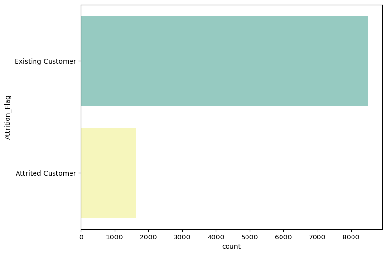

```python
fig, ax = plt.subplots(figsize = (8, 6))
# fig = graficul exterior, ax = interiorul
ax = sns.countplot(data = data, y = 'Attrition_Flag', palette = 'Set3')
plt.show()
```

```python
data['Attrition_Flag'] = data['Attrition_Flag'].map({'Existing Customer':0,'Attrited Customer':1})
# Schimbare in valori binare pentru prelucrare ulterioare
```

```python
round(data['Attrition_Flag'].value_counts()/len(data) * 100, 2) # Verificam ca procentele nu s-au modificat
```

```
0    83.93
1    16.07
Name: Attrition_Flag, dtype: float64
```

### 3. Analiza tuturor variabilelor categorice

```python
# Selectare variabile categorice
categorical_columns = [col for col in data.columns if data[col].dtypes == 'object']
```

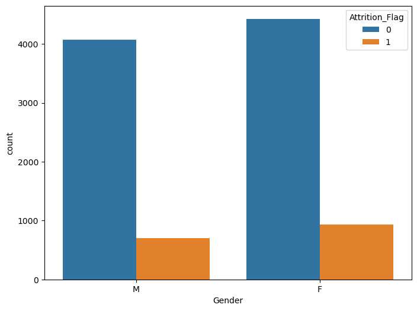

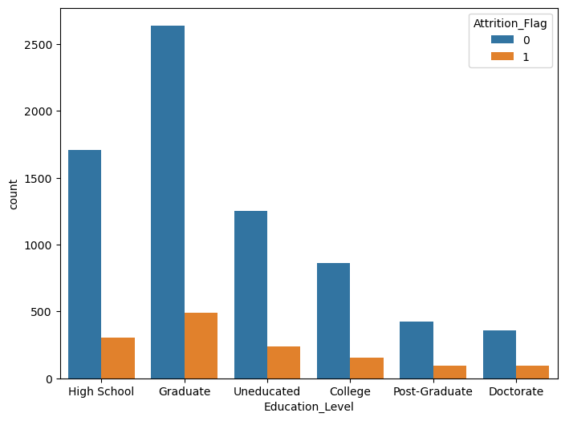

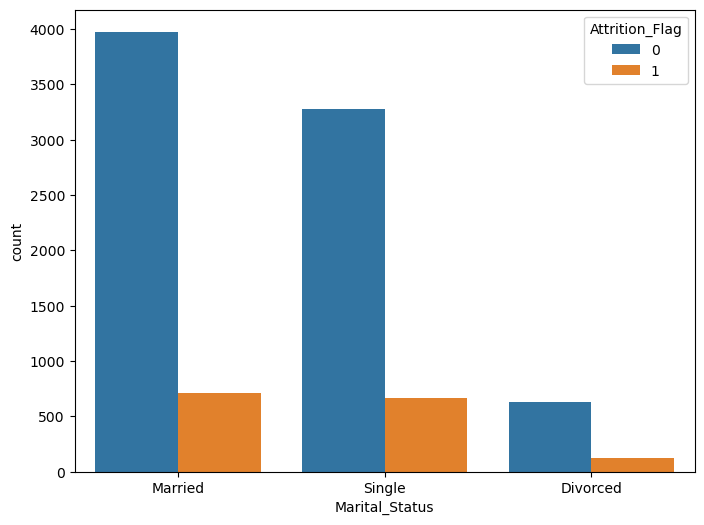

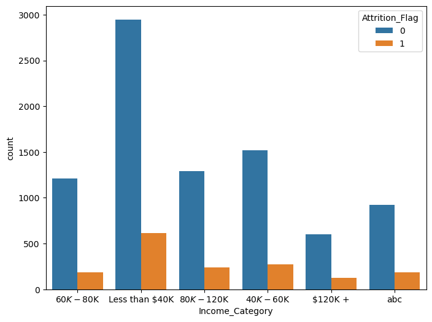

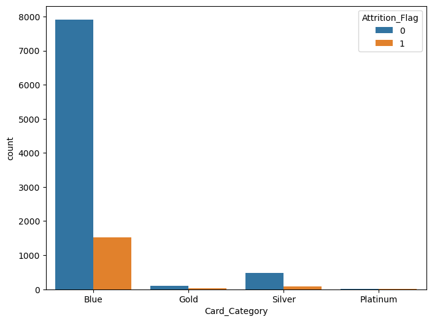

```python
# Analiza distributiei variabilelor categorice in raport cu variabila vizata 'Attrition_Flag'
for col in categorical_columns:
    fig, ax = plt.subplots(figsize = (8,6))
    ax = sns.countplot(data = data, x = col, hue='Attrition_Flag')
    plt.show()
```

```python
# Verificare existenta valori nule
data[categorical_columns].isnull().sum()
```

```
Gender                0
Education_Level    1519
Marital_Status      749
Income_Category       2
Card_Category         0
dtype: int64
```

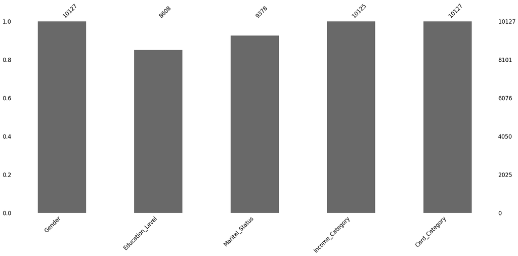

```python
# Vizualizare valori nule
msno.bar(data[categorical_columns])
```

```python
data['Education_Level'].value_counts()
```

```
Graduate         3128
High School      2013
Uneducated       1487
College          1013
Post-Graduate     516
Doctorate         451
Name: Education_Level, dtype: int64
```

```python
# Tratarea valorilor nule pentru nivelul de educatie
# Deoarece acestea sunt foarte multe pentru nivelul de educatie,
# Influentand foarte mult rezultatele, am ales sa elimin valorile respective
data = data.dropna(subset=['Education_Level'])
```

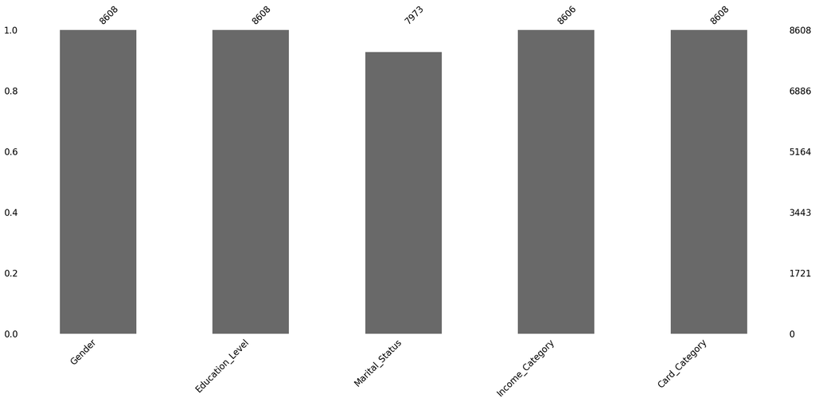

```python
# Vizualizare valori nule #2
msno.bar(data[categorical_columns])
```

```python
# Tratarea celorlalte valori nule, mai putin semnificative

pd.options.mode.chained_assignment = None  # default='warn' # eliminare warnings

data['Marital_Status'] = data['Marital_Status'].fillna('NEDEFINIT')
data['Income_Category'] = data['Income_Category'].fillna('NEDEFINIT')
```

```python
# Verificare existenta valori nule #2
data[categorical_columns].isnull().sum()
```

```
Gender             0
Education_Level    0
Marital_Status     0
Income_Category    0
Card_Category      0
dtype: int64
```

```python
# Cautare coloane cu o singura valoare
data[categorical_columns].nunique()
```

```
Gender             2
Education_Level    6
Marital_Status     4
Income_Category    7
Card_Category      4
dtype: int64
```

```python
data['Income_Category'].value_counts() / len(data) * 100
```

```
Less than $40K    34.897770
$40K - $60K       17.657993
$80K - $120K      15.288104
$60K - $80K       13.847584
abc               11.233736
$120K +            7.051580
NEDEFINIT          0.023234
Name: Income_Category, dtype: float64
```

```python
data['Gender'].value_counts() / len(data) * 100
```

```
F    52.811338
M    47.188662
Name: Gender, dtype: float64
```

```python
data['Marital_Status'].value_counts() / len(data) * 100
```

```
Married      46.456784
Single       38.592007
Divorced      7.574349
NEDEFINIT     7.376859
Name: Marital_Status, dtype: float64
```

```python
data['Card_Category'].value_counts() / len(data) * 100
```

```
Blue        93.122677
Silver       5.541357
Gold         1.138476
Platinum     0.197491
Name: Card_Category, dtype: float64
```

```python
# Stergere inregistrari cu date gresite din Income_Category: venitul nu poate fi 'abc'
data = data[data.Income_Category != 'abc']
```

```python
data['Income_Category'].value_counts() / len(data) * 100
```

```
Less than $40K    39.314226
$40K - $60K       19.892684
$80K - $120K      17.222877
$60K - $80K       15.600052
$120K +            7.943986
NEDEFINIT          0.026175
Name: Income_Category, dtype: float64
```

```python
# Adresarea valorilor rare din Card_Category
data['Card_Category'] = np.where(data['Card_Category'] != 'Blue','Other', data['Card_Category'])
```

```python
data['Card_Category'].value_counts() / len(data) * 100
```

```
Blue     92.998299
Other     7.001701
Name: Card_Category, dtype: float64
```

### 4. Analiza tuturor variabilelor numerice

```python
# Selectare variabile numerice FARA Attrition_Flag
numerical_columns = [col for col in data.columns if data[col].dtypes != 'object' and col != 'Attrition_Flag']
```

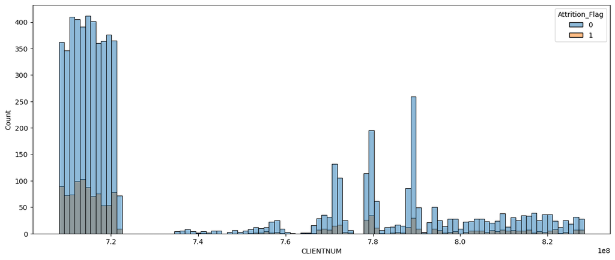

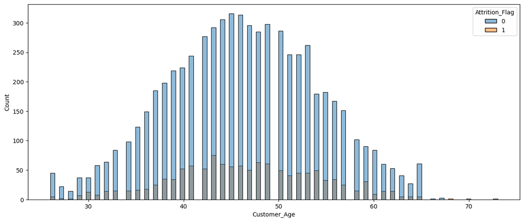

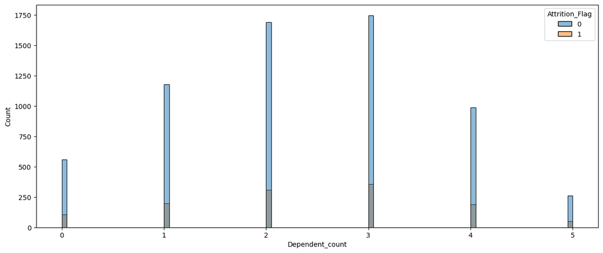

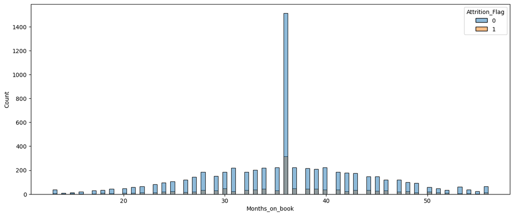

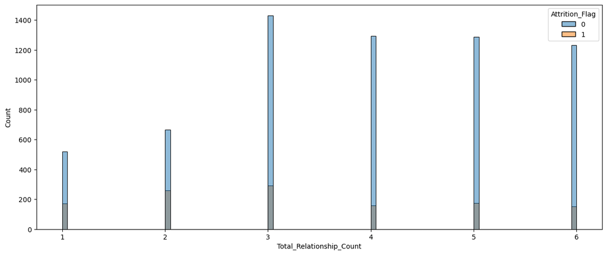

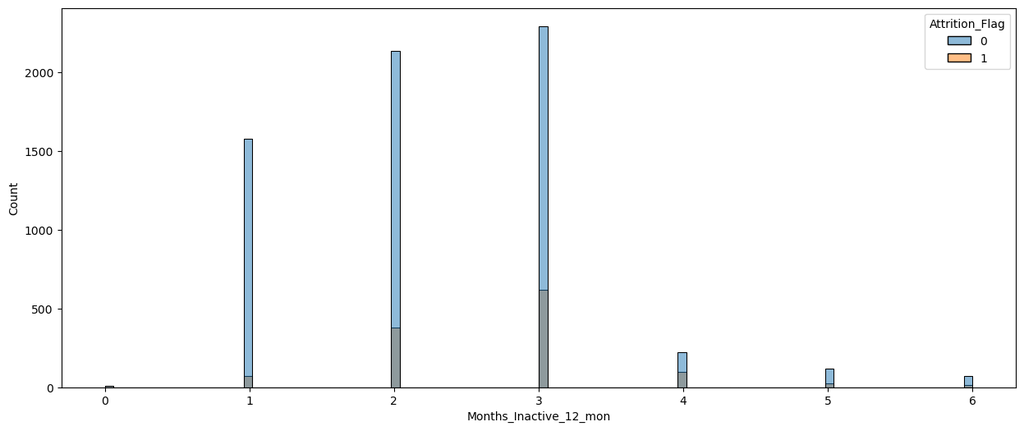

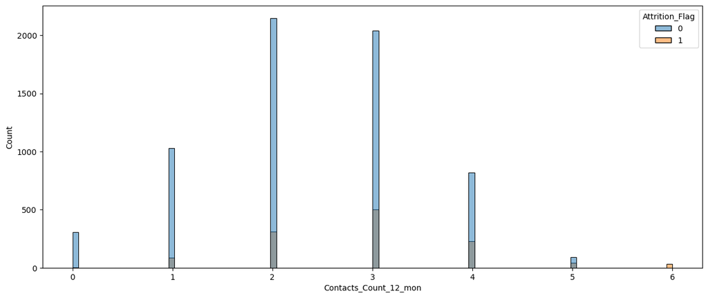

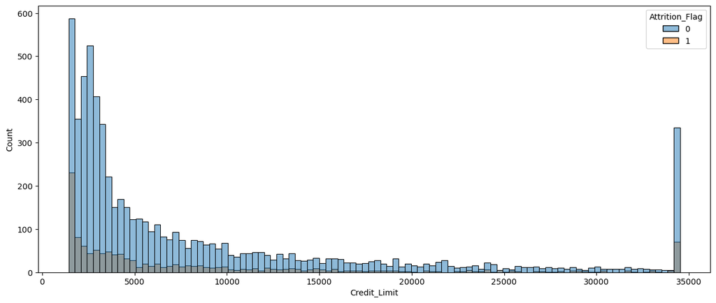

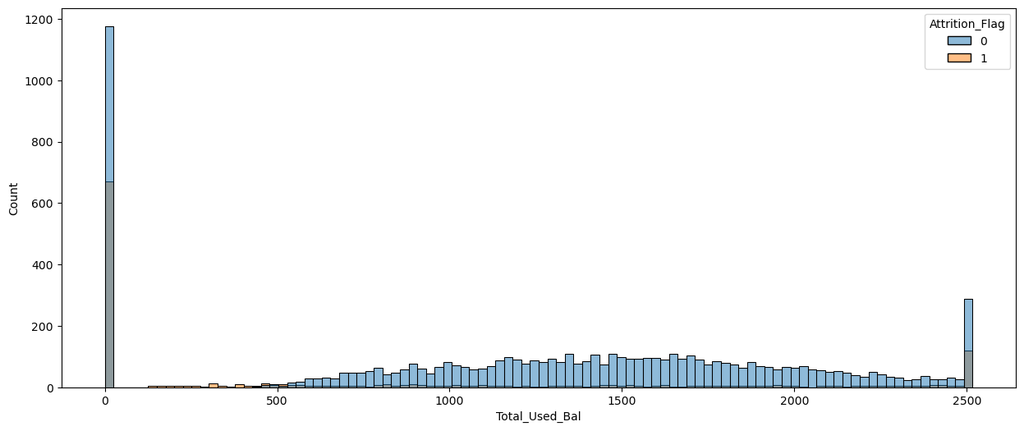

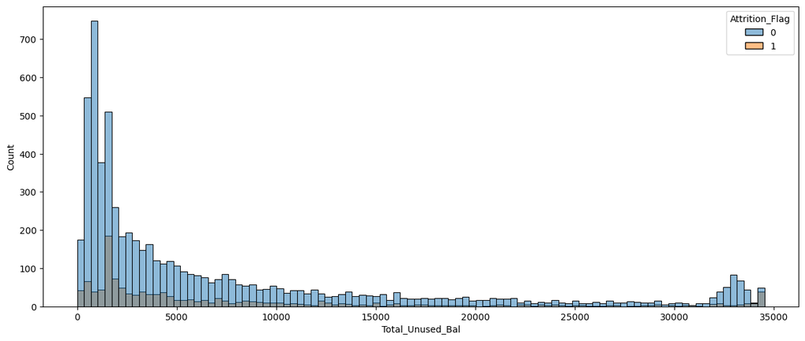

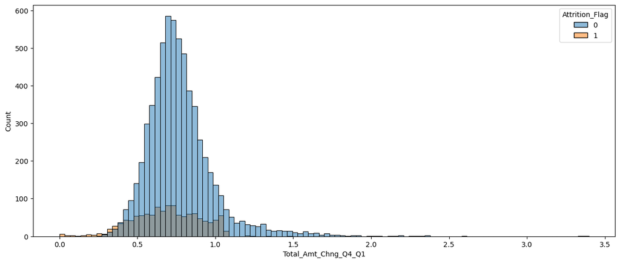

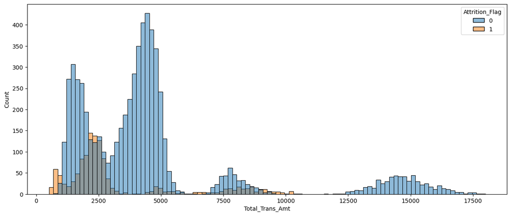

[3 more figures not shown]

```python
# Grafice
for col in numerical_columns:
    fix, ax = plt.subplots(figsize = (15, 6))
    sns.histplot(data = data, x = col, hue = 'Attrition_Flag', bins = 100)
    plt.show()
```

```python
data[numerical_columns].isnull().sum() # Verificare valori nule
```

```
CLIENTNUM                   0
Customer_Age                2
Dependent_count             3
Months_on_book              0
Total_Relationship_Count    0
Months_Inactive_12_mon      0
Contacts_Count_12_mon       0
Credit_Limit                0
Total_Used_Bal              0
Total_Unused_Bal            0
Total_Amt_Chng_Q4_Q1        0
Total_Trans_Amt             0
Total_Trans_Ct              0
Total_Ct_Chng_Q4_Q1         0
Avg_Utilization_Ratio       0
dtype: int64
```

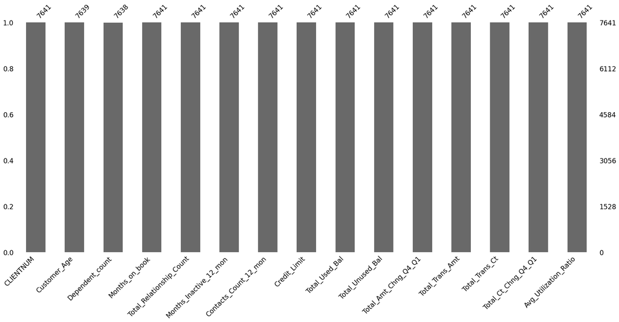

```python
msno.bar(data[numerical_columns])
```

```python
# Inlocuire valori nule cu media
data['Customer_Age'] = data['Customer_Age'].fillna(data['Customer_Age'].mean())
data['Dependent_count'] = data['Dependent_count'].fillna(data['Dependent_count'].mean())
```

```python
# Verificare daca exista variabile constante
data[numerical_columns].nunique()
```

```
CLIENTNUM                   7641
Customer_Age                  46
Dependent_count                7
Months_on_book                44
Total_Relationship_Count       6
Months_Inactive_12_mon         7
Contacts_Count_12_mon          7
Credit_Limit                4955
Total_Used_Bal              1853
Total_Unused_Bal            5471
Total_Amt_Chng_Q4_Q1        1079
Total_Trans_Amt             4382
Total_Trans_Ct               124
Total_Ct_Chng_Q4_Q1          782
Avg_Utilization_Ratio        951
dtype: int64
```